# Decision Trees

```r
library(rpart)
library(rpart.plot)
library(dplyr)
library(tidyverse)
```

```r
thrones <- read_csv("data/character_data_S01-S08.csv")
```

## Data cleaning

Don’t need to scale the data due to the Boolean operations at the nodes

We do still need to remove NAs and do some necessary variable reduction

Some variable engineering required to ensure all columns are numeric or factor

We are going to use our dataset to build a decision tree predicting whether a character will die by the end of the series: - can remove columns directly connected to death - can remove totally irrelevant columns such as name

Then we’ll replace numerics with strings using the data dictionary so that the factor levels have an easily interpretable meaning.

e.g. turn religion = 6 into horse religion

```r
clean_thrones<- thrones %>%
  # Only keep variables of interest
  select(c(sex, religion, occupation, social_status, allegiance_last, allegiance_switched, dth_flag, featured_episode_count, prominence)) %>%
  # Convert to factor level
  mutate(sex = factor(sex, levels = c(1, 2, 9), labels = c("Male", "Female", "Unknown")),
         religion = factor(religion, levels = c(0, 1, 3, 4, 5, 6, 7, 9), labels = c("Great Stallion", "Lord of Light", "Faith of the Seven", "Old Gods", "Drowned God", "Many Faced God", "Other", "Unknown")),
         occupation = factor(occupation, levels = c(1, 2, 9), labels = c("Silk-collar", "Leather-collar", "Unknown")),
         social_status = factor(social_status, levels = c(1, 2, 9), labels = c("Highborn", "Lowborn", "Unknown")),
         allegiance_last = factor(allegiance_last, levels = c(1, 2, 3, 4, 5, 6, 7, 8, 9), labels = c("Stark", "Targaryen", "Night's Watch", "Lannister", "Greyjoy", "Bolton", "Frey", "Other", "Unknown")),
         allegiance_switched = factor(allegiance_switched, levels = c(1, 2, 9), labels = c("No", "Yes", "Unknown")),
         dth_flag = factor(dth_flag, levels = c(0, 1), labels = c("Survived", "Died"))) %>%
  # Remove NAs
  na.omit()

glimpse(clean_thrones)
```

```
Rows: 345
Columns: 9
$ sex                    <fct> Male, Male, Male, Female, Male, Male, Male, Male, Male, Male, Female, Female, Female, Female, Male, Male, F…
$ religion               <fct> Unknown, Unknown, Unknown, Lord of Light, Old Gods, Old Gods, Faith of the Seven, Unknown, Old Gods, Old Go…
$ occupation             <fct> Leather-collar, Leather-collar, Leather-collar, Leather-collar, Leather-collar, Silk-collar, Silk-collar, L…
$ social_status          <fct> Lowborn, Lowborn, Lowborn, Lowborn, Highborn, Highborn, Highborn, Lowborn, Highborn, Highborn, Highborn, Lo…
$ allegiance_last        <fct> Night's Watch, Night's Watch, Night's Watch, Targaryen, Night's Watch, Stark, Stark, Stark, Stark, Other, S…
$ allegiance_switched    <fct> No, No, No, Yes, Yes, No, No, No, No, No, No, No, Yes, Yes, No, Yes, No, Yes, No, No, Yes, No, No, No, No, …
$ dth_flag               <fct> Died, Died, Died, Died, Survived, Survived, Died, Died, Died, Died, Died, Died, Survived, Survived, Died, D…
$ featured_episode_count <dbl> 1, 1, 1, 13, 63, 40, 22, 15, 14, 9, 24, 7, 59, 59, 5, 46, 61, 54, 14, 25, 38, 23, 7, 13, 24, 67, 14, 62, 5,…
$ prominence             <dbl> 1.0000, 1.0000, 1.0000, 1.6250, 6.9041, 4.3836, 2.2759, 1.8750, 1.4237, 1.0000, 2.4828, 0.7778, 6.4658, 6.4…
```

We can see that we have 345 outcomes with 9 variables

## Train/test split

Next, we need to create training and testing data sets

80% training, 20% testing.

Let’s partition the data:

```r
# get how many rows we have in total to work out the percentage
n_data <- nrow(clean_thrones)

# create a test sample index
test_index <- sample(1:n_data, size = n_data*0.2)

# create a test set
thrones_test <- slice(clean_thrones, test_index)

# create a training set
thrones_train <- slice(clean_thrones, -test_index)
```

We can check that our test and training sets have similar proportions of deceased characters.

```r
thrones_test %>%
  tabyl(dth_flag)
```

```
 dth_flag  n   percent
 Survived 27 0.3913043
     Died 42 0.6086957
```

```r
thrones_train %>%
  tabyl(dth_flag)
```

```
 dth_flag   n   percent
 Survived 115 0.4166667
     Died 161 0.5833333
```

Seems ok to me!

## Build a tree model based on training data

Going to use the `rpart` library - stands for recursive partitioning and regression trees

- pass it the target variable (deaths, so `dth_flag`) and the dataset to use (`thrones_train`)
- then pass it the variable we are looking for `class` for categorical and `anova` for continuous

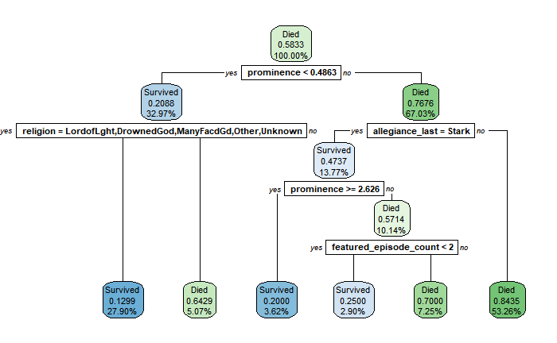

```r
thrones_fit <- rpart(
  formula = dth_flag ~ .,
  data = thrones_train,
  method = "class"
)

rpart.plot(thrones_fit,
           yesno = 2, # 0 = don't write yes/no, 1: write y/n at the top, 2: write y/n at all splits
           fallen.leaves = TRUE,
           faclen = 10,
           digits = 4,
           split.border.col = 1)
```

Variables picked out are the ones deemed most informative for predicting - the rest are discarded

Each node tells us: - predicted survived or died is shown on top line (root node shows us all-data-together prediction) - prob of a died result is on the second line - % of data points that pass through this node on third line - colour related to classification and strength of probability

We can also plot with counts instead of probabilities:

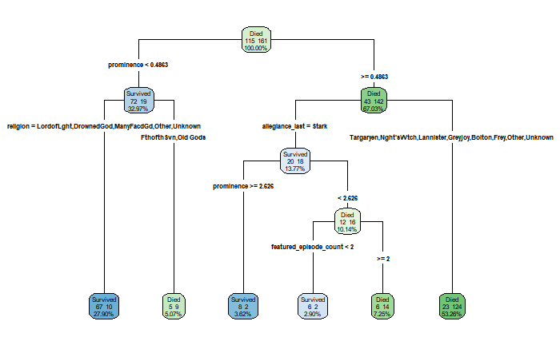

```r
rpart.plot(thrones_fit,
           yesno = 2,
           fallen.leaves = TRUE,
           faclen = 10,
           digits = 4,
           type = 4, # label all nodes, not just leaves
           extra = 101) # displays the number and % of observations in node)
```

We can see the rules used to make the tree if we type:

|  | dth_flag |  |  |  |  |  |  |  |  |  |  |  |  |  |  |  |  |  |  | cover |
| --- | --- | --- | --- | --- | --- | --- | --- | --- | --- | --- | --- | --- | --- | --- | --- | --- | --- | --- | --- | --- |
| 4 | 0.13 | when | prominence | < | 0.49 |  |  |  |  |  |  |  |  |  |  | & | religion | is | Lord of Light or Drowned God or Many Faced God or Other or Unknown | 28% |
| 12 | 0.20 | when | prominence | >= |  |  | 2.63 | & | allegiance_last | is | Stark |  |  |  |  |  |  |  |  | 4% |
| 26 | 0.25 | when | prominence | is | 0.49 | to | 2.63 | & | allegiance_last | is | Stark | & | featured_episode_count | < | 2 |  |  |  |  | 3% |
| 5 | 0.64 | when | prominence | < | 0.49 |  |  |  |  |  |  |  |  |  |  | & | religion | is | Faith of the Seven or Old Gods | 5% |
| 27 | 0.70 | when | prominence | is | 0.49 | to | 2.63 | & | allegiance_last | is | Stark | & | featured_episode_count | >= | 2 |  |  |  |  | 7% |
| 7 | 0.84 | when | prominence | >= |  |  | 0.49 | & | allegiance_last | is | Targaryen or Night's Watch or Lannister or Greyjoy or Bolton or Frey or Other or Unknown |  |  |  |  |  |  |  |  | 53% |

Note: %s are rounded to the neatest whole number - so sometimes won’t make a perfect 100%

## Use trained model to create predictions on the test dataset

| sex | religion | occupation | social_status | allegiance_last | allegiance_switched | dth_flag | featured_episode_count | prominence | pred |
| --- | --- | --- | --- | --- | --- | --- | --- | --- | --- |
| Male | Unknown | Silk-collar | Lowborn | Other | No | Died | 3 | 0.7500 | Died |
| Male | Unknown | Silk-collar | Lowborn | Other | No | Died | 3 | 0.7500 | Died |
| Male | Faith of the Seven | Silk-collar | Lowborn | Other | No | Died | 1 | 1.0000 | Died |
| Male | Unknown | Silk-collar | Highborn | Stark | No | Survived | 1 | 1.0000 | Survived |
| Male | Unknown | Leather-collar | Lowborn | Stark | No | Survived | 1 | 0.2000 | Survived |
| Male | Unknown | Leather-collar | Highborn | Targaryen | Yes | Died | 24 | 2.8571 | Died |
| Male | Unknown | Leather-collar | Lowborn | Lannister | No | Survived | 4 | 0.4444 | Survived |
| Male | Unknown | Leather-collar | Lowborn | Stark | No | Survived | 1 | 0.2000 | Survived |
| Male | Unknown | Leather-collar | Lowborn | Unknown | No | Survived | 1 | 0.1316 | Survived |
| Male | Unknown | Leather-collar | Lowborn | Bolton | No | Died | 4 | 0.4848 | Survived |

[output cut: 59 more lines]

| prominence | religion | allegiance_last | featured_episode_count | dth_flag | pred |
| --- | --- | --- | --- | --- | --- |
| 0.7500 | Unknown | Other | 3 | Died | Died |
| 0.7500 | Unknown | Other | 3 | Died | Died |
| 1.0000 | Faith of the Seven | Other | 1 | Died | Died |
| 1.0000 | Unknown | Stark | 1 | Survived | Survived |
| 0.2000 | Unknown | Stark | 1 | Survived | Survived |
| 2.8571 | Unknown | Targaryen | 24 | Died | Died |
| 0.4444 | Unknown | Lannister | 4 | Survived | Survived |
| 0.2000 | Unknown | Stark | 1 | Survived | Survived |
| 0.1316 | Unknown | Unknown | 1 | Survived | Survived |
| 0.4848 | Unknown | Bolton | 4 | Died | Survived |

[output cut: 59 more lines]

## Checking model performance

We can create a confusion matrix again to check performance.

Values read from the left are predicted, values from the top down are actual values - we tell `conf_mat()` which variable is the true value and predicted value using the arguments: `truth` and `estimate`

```r
conf_mat
```

```
          Truth
Prediction Survived Died
  Survived       22    5
  Died            5   37
```

Accurate decision tree = higher main diagonal values (top left - bottom right)

Calculate probability of prediction being correct:

| .metric | .estimator | .estimate |
| --- | --- | --- |
| accuracy | binary | 0.8550725 |

the `.estimate` column in the output shows you the probability of correctly predicting whether a character in the test set died or not in the series.

We can also calculate the **sensitivity** (AKA the true positive rate) and the **specificity** (AKA true negative rate) using other `yardstick` functions

```r
thrones_test_pred %>%
  sensitivity(truth = dth_flag, estimate = pred)
```

| .metric | .estimator | .estimate |
| --- | --- | --- |
| sensitivity | binary | 0.8148148 |

```r
thrones_test_pred %>%
  specificity(truth = dth_flag, estimate = pred)
```

| .metric | .estimator | .estimate |
| --- | --- | --- |
| specificity | binary | 0.8809524 |

```r
library(caret)

prediction = predict(thrones_fit, newdata = thrones_test, type = 'class')
confusionMatrix(prediction, thrones_test$dth_flag)
```

[output not shown]

Congrats on creating a decision tree!

**Advantages**: - intuitively easy to explain - closely mirror human decision making compared to e.g. regression - graphical display - easily handle qualitative predictors with the need for dummy variables - not sensitive to scale of variables

**Disadvantages** - trees generally do not have the same level of predictive accuracy as other approaches - since they’re not quite as robust - a small change in the data can cause a large change in th final estimated tree

## Random forests

To make this method more robust, the **random forest** algorithm has been developed.

This involes a collection of decision trees (generated by bootstrapping your training data)

Instead of searching for the most important feature while splitting a node, it searches for the best feature among a random subset of features.

A forest: a collection of decision trees that have been built which each have their own class prediction - the class with the most votes becomes our model prediction.

e.g. if 50 of your trees predict an outcome as true and 10 predict false, the overall prediction of the forest will be true

```r
rf_classifier
```

```
Ranger result

Call:
 ranger(dth_flag ~ ., data = thrones_train, importance = "impurity",      num.trees = 1000, mtry = 2, min.node.size = 5)

Type:                             Classification
Number of trees:                  1000
Sample size:                      276
Number of independent variables:  8
Mtry:                             2
Target node size:                 5
Variable importance mode:         impurity
Splitrule:                        gini
OOB prediction error:             21.38 %
```

*Hyperparameters*

train on training set 80/100 test on testing set 20/100

adding validation, split this something like 60/20/20

train on training set 60/100 test on testing set 20/100 validation on validation set 20/20

When we’re happy that the model performs well enough to the validation dataset

combine the val data and train

test again

k-fold cv includes the validation process, so you might be fine just validating that way.

```r
rf_classifier
```

```
Ranger result

Call:
 ranger(dth_flag ~ ., data = thrones_train, importance = "impurity",      num.trees = 1000, mtry = 2, min.node.size = 5)

Type:                             Classification
Number of trees:                  1000
Sample size:                      276
Number of independent variables:  8
Mtry:                             2
Target node size:                 5
Variable importance mode:         impurity
Splitrule:                        gini
OOB prediction error:             21.38 %
```

```r
sort(importance(rf_classifier), decreasing = TRUE)
```

```
            prominence featured_episode_count        allegiance_last               religion             occupation
             43.951883              15.184153              14.344745               8.733501               8.479294
                   sex          social_status    allegiance_switched
              5.522245               3.214420               1.982202
```

```r
confusionMatrix(thrones_test_pred$pred, thrones_test_pred$dth_flag)
```

```
Confusion Matrix and Statistics

          Reference
Prediction Survived Died
  Survived       22    5
  Died            5   37

               Accuracy : 0.8551
                 95% CI : (0.7496, 0.9283)
    No Information Rate : 0.6087
    P-Value [Acc > NIR] : 7.263e-06

                  Kappa : 0.6958

 Mcnemar's Test P-Value : 1

            Sensitivity : 0.8148
            Specificity : 0.8810
         Pos Pred Value : 0.8148
         Neg Pred Value : 0.8810
             Prevalence : 0.3913
         Detection Rate : 0.3188
   Detection Prevalence : 0.3913
      Balanced Accuracy : 0.8479

       'Positive' Class : Survived
```